# Bears, Bots, Biased Training Data

Feb 24, 2022

## Introduction

I recently started fast.ai's free [Practical Deep Learning for Coders course](https://course.fast.ai/). I have really enjoyed the first couple lessons. I always thought I needed to build up more programming skills before starting with machine learning. The course has a very different approach. They emphasize getting up and running, and filling in the detailed bits later. Their analogy (borrowed from Harvard professor David Perkins) is if you are going to teach someone to play baseball, you take them to a game. You don't start with the physics of the ball travelling through the air. It is a lot more interesting to learn the tricky bits when you have context for why you need them.

One of the early lessons focuses on training a model to classify images of bears. I want to extend that out for a couple reasons:

1. I'm curious how a simple model like this will be affected by biased data
2. It lets me play around with more Python code and attempt publishing a Jupyter notebook using Jekyll

So if you are well-versed in machine learning and Jupyter notebooks, this post probably is not for you. But I'm guessing you figured that out already. For the rest of you, let's classify some bears.

## Install Packages

The course uses fast.ai's own software, which sits on top of PyTorch to be extra user-friendly. Everything ultimately runs in Python.

```python
!pip install -Uqq fastbook
import fastbook
fastbook.setup_book()
```

```python
from fastbook import *
from fastai.vision.widgets import *
```

## Downloading Images

The course walks you through downloading images with Bing Image Search, by signing up for a [Microsoft Azure](https://azure.microsoft.com/en-us/services/cognitive-services/bing-web-search-api/) free account. Which ultimately gives you a search key:

```python
import os
key = os.environ.get('AZURE_SEARCH_KEY', 'HIDDEN')
```

I am going to set up the initial bear classification model quite similarly to how it is done in the course. The goal will be to classify images of three bear types:

```python
bear_types = 'grizzly','black','polar'
path = Path('bears')
```

First we need the bear images we will use to train and validate the model. We do this by making a directory for each bear type, and then using the `search_images_bing` function to get 60 images of each bear type, which we then download. Note: in the course they use the default max images of 150, but I have kept it to 60 here for reasons I will discuss later.

```python
if not path.exists():
    path.mkdir()
    for o in bear_types:
        dest = (path/o)
        dest.mkdir(exist_ok=True)
        results = search_images_bing(key, f'{o} bear', max_images = 60)
        download_images(dest, urls=results.attrgot('contentUrl'))
```

Next, the course walks you through getting the image file paths and checking if there are any image errors. If there are, the images identified as failed are removed.

```python
fns = get_image_files(path)
fns
```

```
(#171) [Path('bears/grizzly/00000047.jpg'),Path('bears/grizzly/00000055.jpg'),Path('bears/grizzly/00000036.jpg'),Path('bears/grizzly/00000030.jpg'),Path('bears/grizzly/00000029.jpg'),Path('bears/grizzly/00000035.jpg'),Path('bears/grizzly/00000000.jpg'),Path('bears/grizzly/00000044.jpg'),Path('bears/…
```

```python
failed = verify_images(fns)
failed
```

```
(#0) []
```

```python
failed.map(Path.unlink);
```

## From Data to DataLoaders

Now that we have the images, we need to organize them for training our model. The course shows you how to do this using `DataBlock`. We will save 20% of the images for a validation set, while the other 80% of the images will be used to train the model.

```python
bears = DataBlock(
    blocks=(ImageBlock, CategoryBlock),
    get_items=get_image_files,
    splitter=RandomSplitter(valid_pct=0.2, seed=42),
    get_y=parent_label,
    item_tfms=Resize(128))
```

Now we load the bear images into the structure we specified.

```python
dls = bears.dataloaders(path)
```

## Training the Model

The course also spends some time on data augmentation. For training this model we use `RandomResizedCrop` which crops a different portion of the image with each pass. This ensures all images are cropped to the same size for passing to the model, but the random resizing also guards against missing important features of the image. The course lesson has a lot more information on this.

```python
bears = bears.new(
    item_tfms=RandomResizedCrop(224, min_scale=0.5),
    batch_tfms=aug_transforms())
dls = bears.dataloaders(path)
```

With the data all set, we can now use the pre-trained `resnet18` model, and train it up for recognizing images of black, grizzly and polar bears.

```python
learn = cnn_learner(dls, resnet18, metrics=error_rate)
learn.fine_tune(4)
```

```
Downloading: "https://download.pytorch.org/models/resnet18-f37072fd.pth" to /root/.cache/torch/hub/checkpoints/resnet18-f37072fd.pth
```

| epoch | train_loss | valid_loss | error_rate | time |
| --- | --- | --- | --- | --- |
| 0 | 1.908846 | 1.764573 | 0.441176 | 00:16 |

| epoch | train_loss | valid_loss | error_rate | time |
| --- | --- | --- | --- | --- |
| 0 | 0.917806 | 0.620768 | 0.235294 | 00:14 |
| 1 | 0.708314 | 0.118062 | 0.058824 | 00:14 |
| 2 | 0.497561 | 0.051072 | 0.029412 | 00:16 |
| 3 | 0.379105 | 0.033391 | 0.000000 | 00:13 |

Even with just 60 images of each bear type, by the fourth epoch (an epoch represents one pass of the model through the training data) we arrive at an error rate of 0% (all validation images properly identified). We can show this better in a confusion matrix:

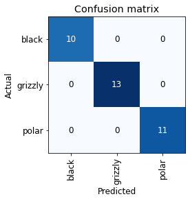

```python
interp = ClassificationInterpretation.from_learner(learn)
interp.plot_confusion_matrix()
```

We see that the validation set of 10 black bears, 13 grizzly bears and 11 polar bears were all predicted correctly. We can also see which predictions the model was least confident in, even though all were ultimately correct:

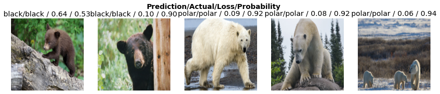

```python
interp.plot_top_losses(5, nrows=1)
```

The course also gives you instructions on how to clean the data if you need. But we will stop there for the first model.

## Using Biased Data

As someone who is very interested in the ethics of machine learning, I want to do a quick experiment on how our model would turn out if our bears images were heavily biased. There are all kinds of real-world instances where image classifiers were trained on biased data with significant performance results. There is a well-known case identified by MIT researcher and founder of the Algorithmic Justice League, Joy Buolamwini. Her Ted Talk about it is [here](https://www.ted.com/talks/joy_buolamwini_how_i_m_fighting_bias_in_algorithms).

Let's see how a new model performs based on 150 images of polar bears and 15 images each of black and grizzly bears, rather than the 60/60/60 set used earlier. This is the same number of images overall, but heavily skewed to polar bears. This mirrors many biased datasets of images of humans, where the vast majority are images of white people.

```python
path2 = Path('bears2')
```

We make directories similar to before, but with some adjustments to specify the new numbers of images:

```python
if not path2.exists():
    path2.mkdir()
    for o in bear_types:
        dest = (path2/o)
        dest.mkdir(exist_ok=True)
        if o == 'polar':
            results = search_images_bing(key, f'{o} bear', max_images=150)
        else:
            results = search_images_bing(key, f'{o} bear', max_images=15)
        download_images(dest, urls=results.attrgot('contentUrl'))
```

We then verify all of the images for this set:

```python
fns = get_image_files(path2)
fns
```

```
(#173) [Path('bears2/grizzly/00000000.jpg'),Path('bears2/grizzly/00000002.jpeg'),Path('bears2/grizzly/00000010.jpg'),Path('bears2/grizzly/00000009.jpg'),Path('bears2/grizzly/00000008.jpg'),Path('bears2/grizzly/00000006.jpg'),Path('bears2/grizzly/00000004.jpg'),Path('bears2/grizzly/00000011.jpg'),Pat…
```

```python
failed = verify_images(fns)
failed
```

```
(#0) []
```

```python
failed.map(Path.unlink);
```

And now we load the data with same data block structure from above, with the same data augmentation as well.

```python
bears2 = DataBlock(
    blocks=(ImageBlock, CategoryBlock),
    get_items=get_image_files,
    splitter=RandomSplitter(valid_pct=0.2, seed=42),
    get_y=parent_label,
    item_tfms=Resize(128))
```

```python
dls2 = bears2.dataloaders(path2)
```

```python
bears2 = bears2.new(
    item_tfms=RandomResizedCrop(224, min_scale=0.5),
    batch_tfms=aug_transforms())
dls2 = bears2.dataloaders(path2)
```

## The New Model

Let's see what sort of error rate the same training instructions give us:

```python
learn2 = cnn_learner(dls2, resnet18, metrics=error_rate)
learn2.fine_tune(4)
```

| epoch | train_loss | valid_loss | error_rate | time |
| --- | --- | --- | --- | --- |
| 0 | 1.961362 | 2.611108 | 0.705882 | 00:14 |

| epoch | train_loss | valid_loss | error_rate | time |
| --- | --- | --- | --- | --- |
| 0 | 1.648179 | 1.457548 | 0.470588 | 00:13 |
| 1 | 1.500955 | 0.667681 | 0.323529 | 00:13 |
| 2 | 1.308574 | 0.390849 | 0.176471 | 00:13 |
| 3 | 1.186422 | 0.336911 | 0.088235 | 00:15 |

We see that even though we gave the model the same total number of images, the biased data predictably led to a model that is less accurate with an 8.8% error rate (which is still pretty good). Let's see what that looks like in a confusion matrix:

```
interp = ClassificationInterpretation.from_learner(learn2)
interp.plot_confusion_matrix()
```

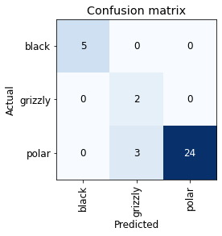

I was surprised to see the model correctly identify the smaller number of black and grizzly bears in the validation set. The errors actually came from mis-identifying polar bears in the set. But I suppose this makes sense. If the model struggles to identify black and grizzly bears due to reduced data, it will also have a hard time deciding if a polar bear is truly a polar bear, or one of those other types. Let's have a look at some of those errors:

```
interp.plot_top_losses(5, nrows=1)
```

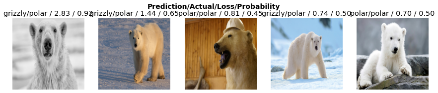

The mis-identified polar bear images all look quite polar-bear-like to my eye, though the first one is a bit distorted, and possibly a computer-generated image. It is also important to note that the top five losses (loss is the model's metric for evaluating its predictions) are all higher than the top loss from the model we trained earlier. So the model we trained from biased data led to more errors, and less overall confidence in its predictions.

Conclusion

It probably is not shocking to see that biased training data negatively affects model performance. It is important to note that using balanced data does not clear all of the ethical issues with our bear classifier, either. Even if the model "performs" better, its intended use is massively important. The issue with facial recognition products is not only that they struggle with identifying underrepresented individuals. Many of their intended applications should not even be pursued in the first place. Bias in machine learning extends far beyond biased training data alone.

That said, it was neat to put together a simple case like this after a couple lessons of the fast.ai course. Their software is super easy to use and the course is set up in a very thoughtful way. Jupyter is also wonderful to work with and I will certainly be back. Thanks for following along!